# Experiments with groups of stations: flood_generating_process quantiles

FBK

9 januar 2017

## QS

[1] “QS” [1] 2 [1] 10 11 13 18 20 25 38 39 43 49 50 57 77 117 152 153 160 [18] 161 168 174 188 189 202 208 214 222 231 233 235 240 242 244 245 246 [35] 247 251 252 254 289 298 [1] “done printint”

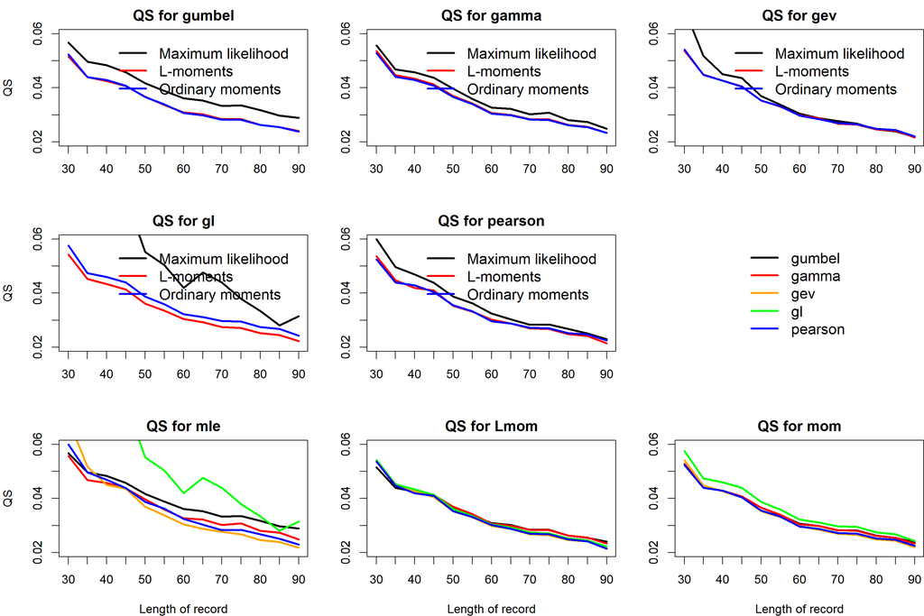

[1] “QS” [1] 2 [1] 1 12 15 16 17 21 27 34 40 42 45 46 56 58 111 116 119 [18] 120 121 122 123 124 144 149 150 156 166 176 180 197 203 224 229 230 [35] 234 237 256 288 290 [1] “done printint”

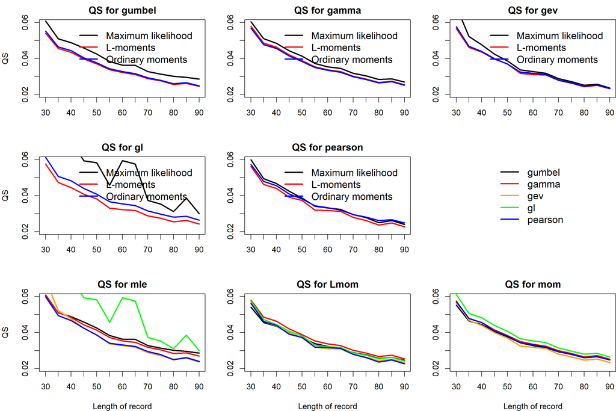

[1] “QS” [1] 2 [1] 14 19 23 28 29 33 44 59 64 65 69 97 103 105 106 107 108 [18] 112 125 126 130 132 133 134 141 142 145 157 171 175 179 182 185 201 [35] 216 220 227 262 279 [1] “done printint”

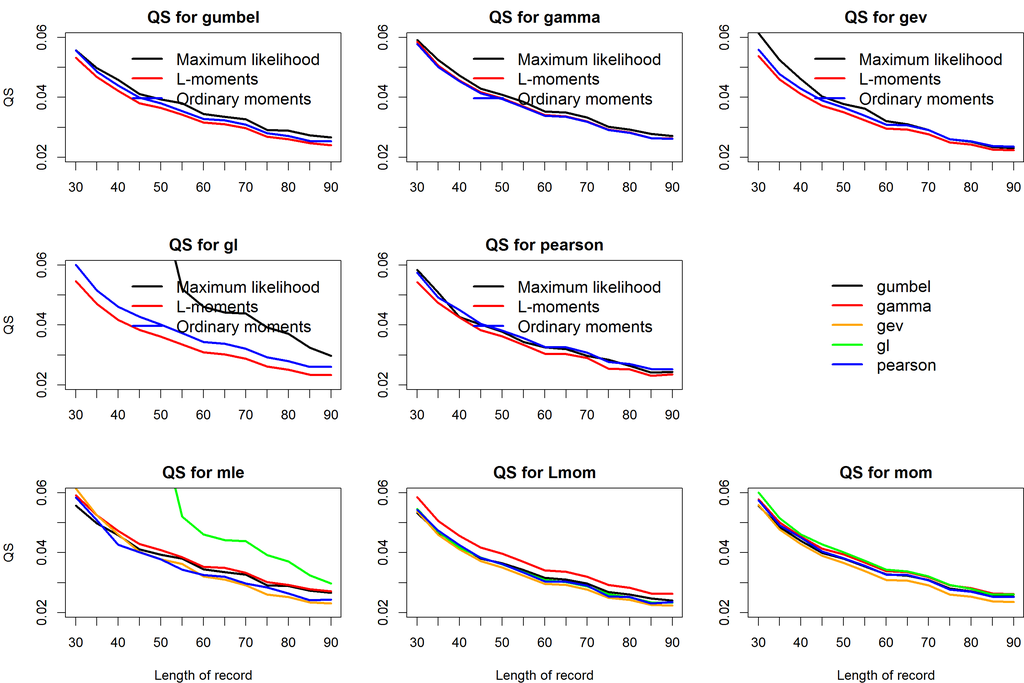

[1] “QS” [1] 2 [1] 22 31 32 41 60 61 62 63 66 67 68 74 75 78 80 81 82 [18] 83 84 85 88 91 92 93 94 96 102 109 110 127 128 136 138 140 [35] 147 163 165 204 283 291 [1] “done printint”

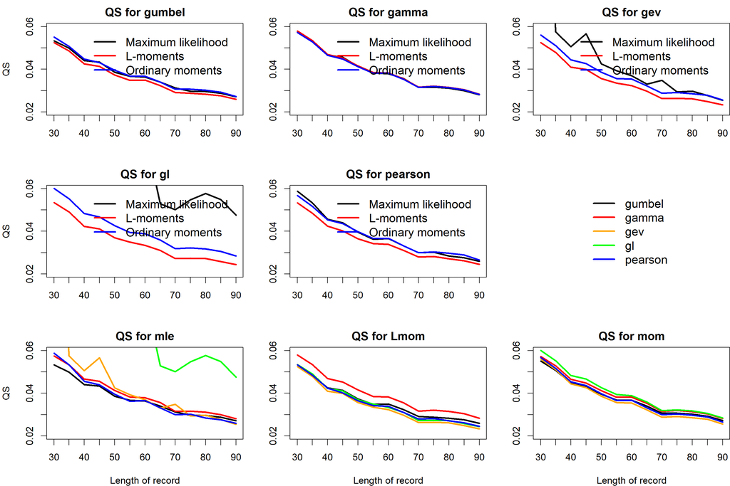

## BS

[1] “BS” [1] 2 [1] 10 11 13 18 20 25 38 39 43 49 50 57 77 117 152 153 160 [18] 161 168 174 188 189 202 208 214 222 231 233 235 240 242 244 245 246 [35] 247 251 252 254 289 298 [1] “done printint”

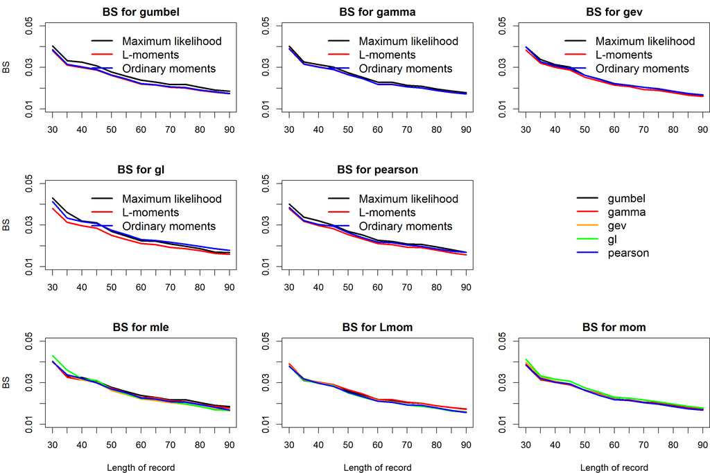

[1] “BS” [1] 2 [1] 1 12 15 16 17 21 27 34 40 42 45 46 56 58 111 116 119 [18] 120 121 122 123 124 144 149 150 156 166 176 180 197 203 224 229 230 [35] 234 237 256 288 290 [1] “done printint”

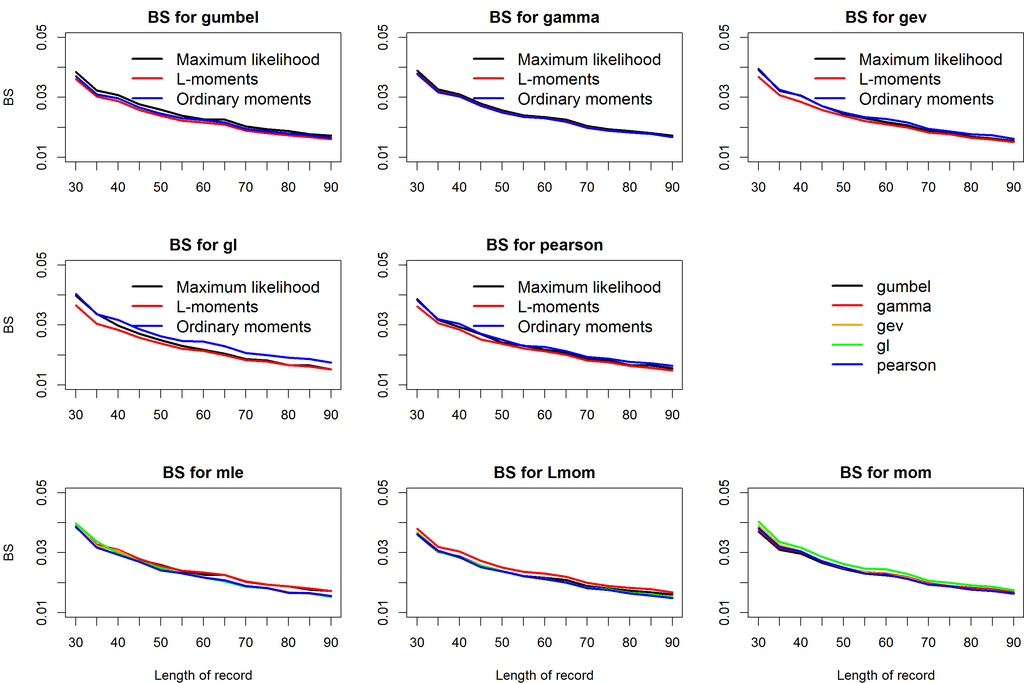

[1] “BS” [1] 2 [1] 14 19 23 28 29 33 44 59 64 65 69 97 103 105 106 107 108 [18] 112 125 126 130 132 133 134 141 142 145 157 171 175 179 182 185 201 [35] 216 220 227 262 279 [1] “done printint”

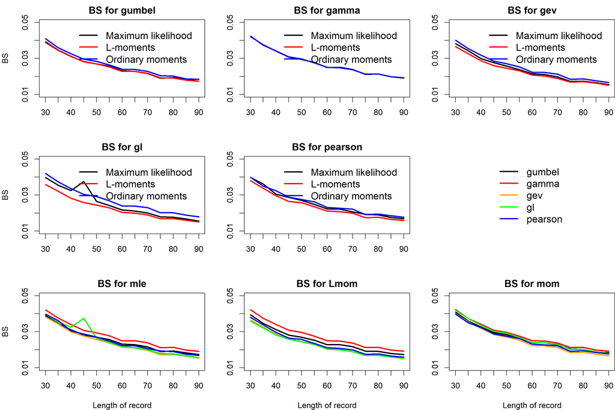

[1] “BS” [1] 2 [1] 22 31 32 41 60 61 62 63 66 67 68 74 75 78 80 81 82 [18] 83 84 85 88 91 92 93 94 96 102 109 110 127 128 136 138 140 [35] 147 163 165 204 283 291 [1] “done printint”

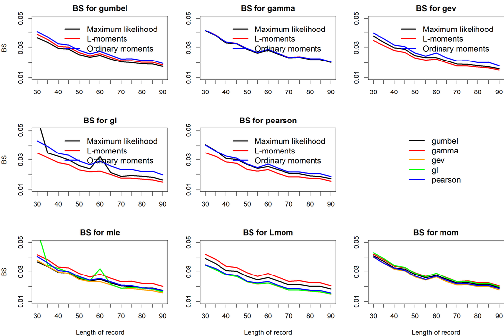

## Return levels

#### RL 10y

[1] “r.levels” [1] 10 [1] 10 11 13 18 20 25 38 39 43 49 50 57 77 117 152 153 160 [18] 161 168 174 188 189 202 208 214 222 231 233 235 240 242 244 245 246 [35] 247 251 252 254 289 298 [1] “done printint”

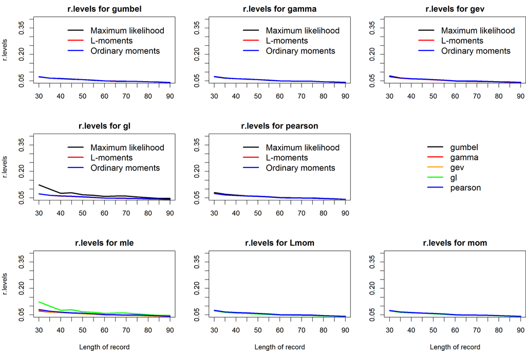

[1] “r.levels” [1] 10 [1] 1 12 15 16 17 21 27 34 40 42 45 46 56 58 111 116 119 [18] 120 121 122 123 124 144 149 150 156 166 176 180 197 203 224 229 230 [35] 234 237 256 288 290 [1] “done printint”

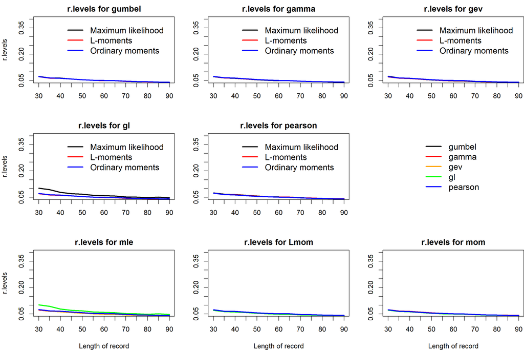

[1] “r.levels” [1] 10 [1] 14 19 23 28 29 33 44 59 64 65 69 97 103 105 106 107 108 [18] 112 125 126 130 132 133 134 141 142 145 157 171 175 179 182 185 201 [35] 216 220 227 262 279 [1] “done printint”

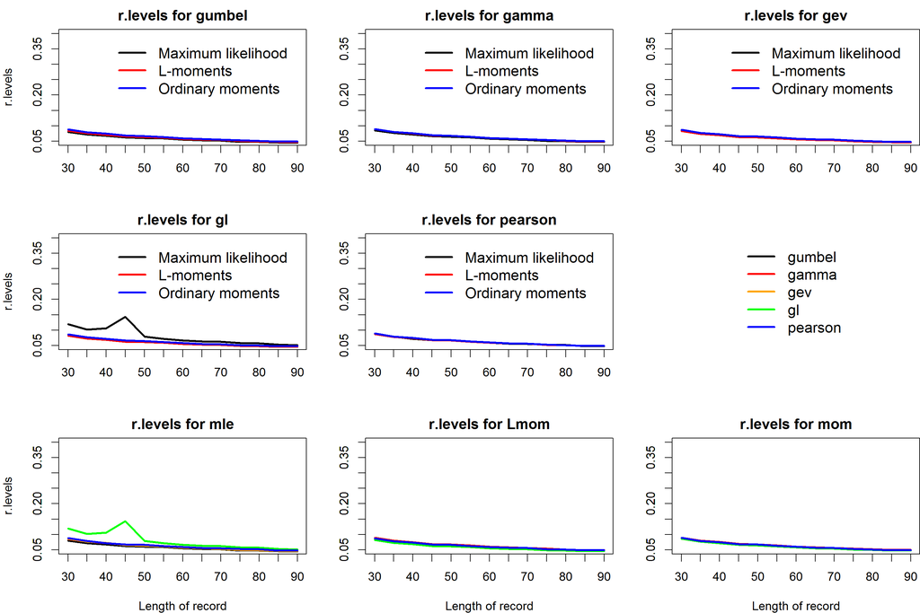

[1] “r.levels” [1] 10 [1] 22 31 32 41 60 61 62 63 66 67 68 74 75 78 80 81 82 [18] 83 84 85 88 91 92 93 94 96 102 109 110 127 128 136 138 140 [35] 147 163 165 204 283 291 [1] “done printint”

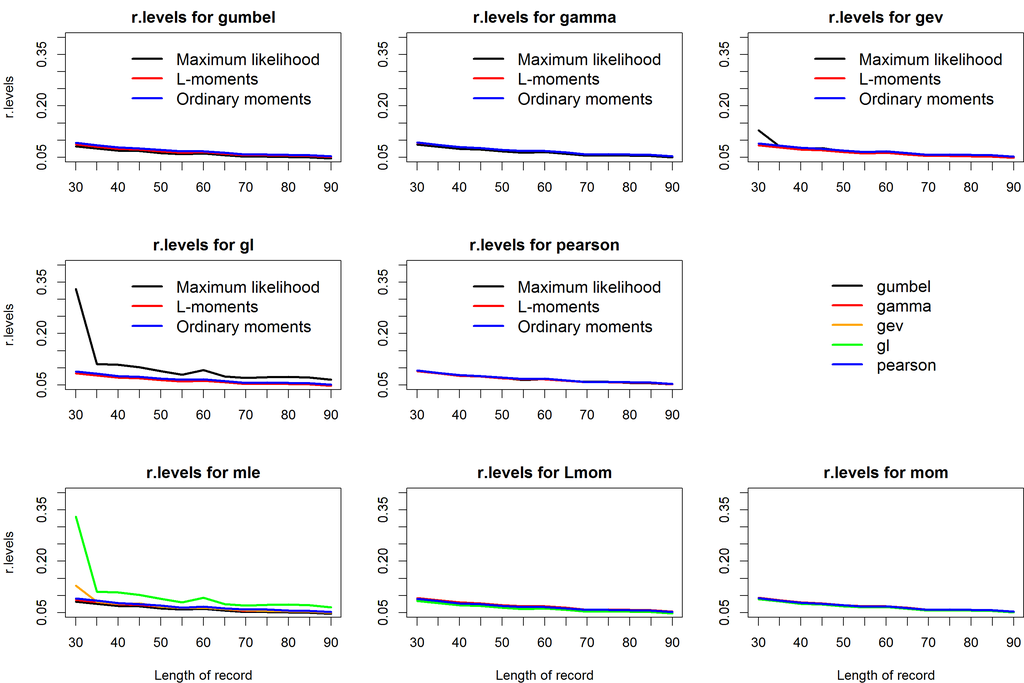

#### RL 100y

[1] “r.levels” [1] 100 [1] 10 11 13 18 20 25 38 39 43 49 50 57 77 117 152 153 160 [18] 161 168 174 188 189 202 208 214 222 231 233 235 240 242 244 245 246 [35] 247 251 252 254 289 298 [1] “done printint”

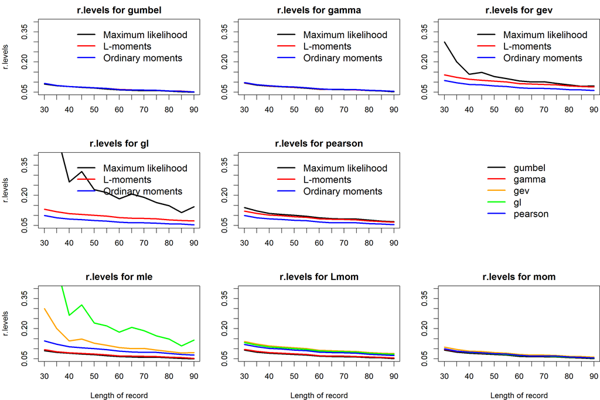

[1] “r.levels” [1] 100 [1] 1 12 15 16 17 21 27 34 40 42 45 46 56 58 111 116 119 [18] 120 121 122 123 124 144 149 150 156 166 176 180 197 203 224 229 230 [35] 234 237 256 288 290 [1] “done printint”

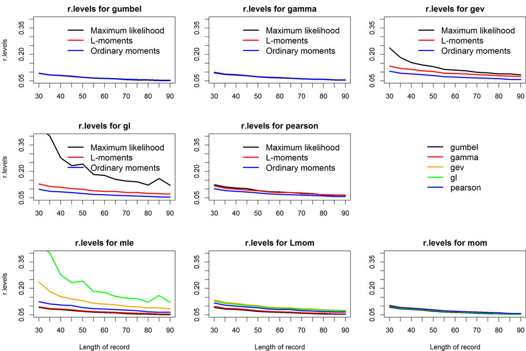

[1] “r.levels” [1] 100 [1] 14 19 23 28 29 33 44 59 64 65 69 97 103 105 106 107 108 [18] 112 125 126 130 132 133 134 141 142 145 157 171 175 179 182 185 201 [35] 216 220 227 262 279 [1] “done printint”

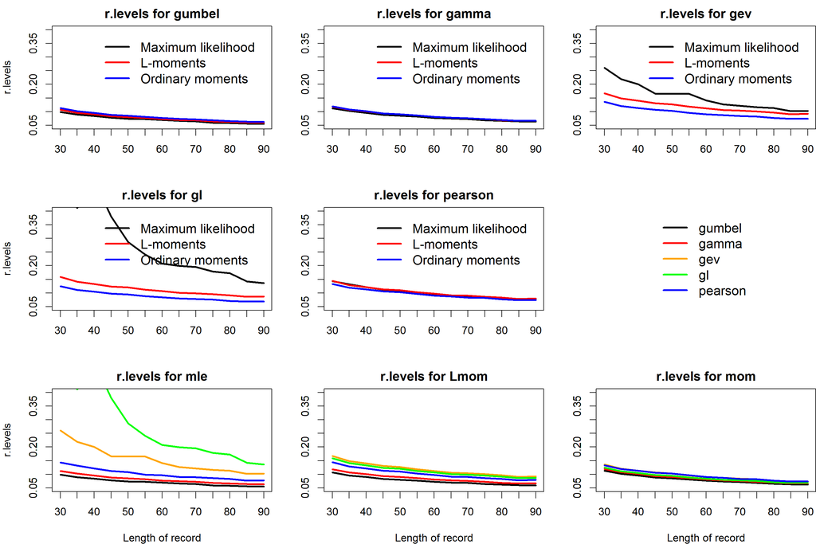

[1] “r.levels” [1] 100 [1] 22 31 32 41 60 61 62 63 66 67 68 74 75 78 80 81 82 [18] 83 84 85 88 91 92 93 94 96 102 109 110 127 128 136 138 140 [35] 147 163 165 204 283 291 [1] “done printint”

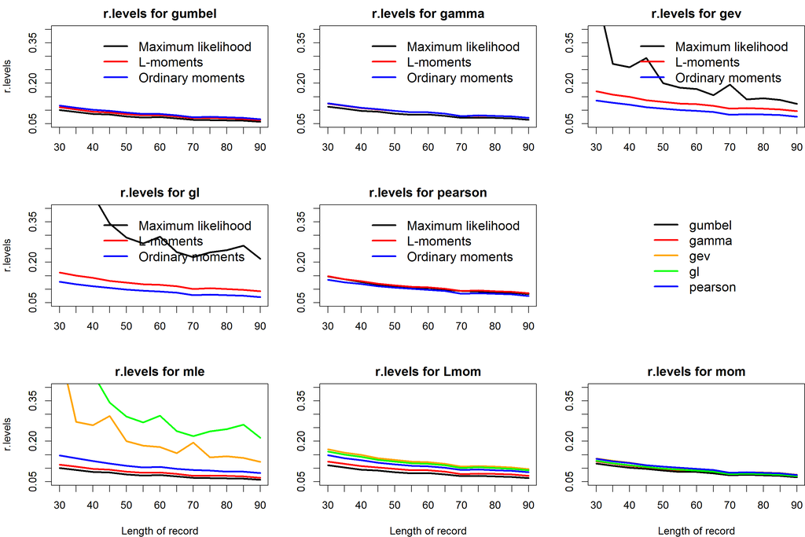

#### RL 200y

[1] “r.levels” [1] 200 [1] 10 11 13 18 20 25 38 39 43 49 50 57 77 117 152 153 160 [18] 161 168 174 188 189 202 208 214 222 231 233 235 240 242 244 245 246 [35] 247 251 252 254 289 298 [1] “done printint”

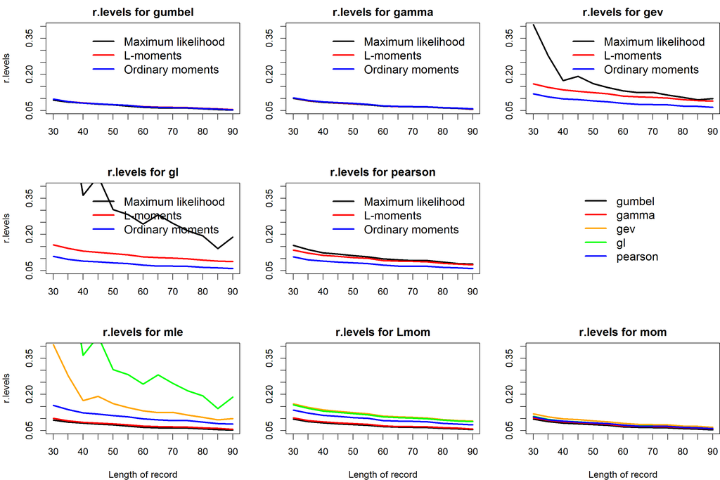

[1] “r.levels” [1] 200 [1] 1 12 15 16 17 21 27 34 40 42 45 46 56 58 111 116 119 [18] 120 121 122 123 124 144 149 150 156 166 176 180 197 203 224 229 230 [35] 234 237 256 288 290 [1] “done printint”

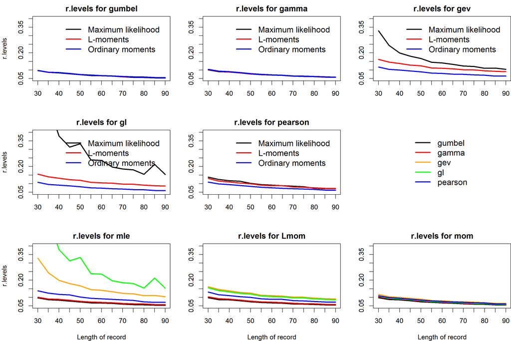

[1] “r.levels” [1] 200 [1] 14 19 23 28 29 33 44 59 64 65 69 97 103 105 106 107 108 [18] 112 125 126 130 132 133 134 141 142 145 157 171 175 179 182 185 201 [35] 216 220 227 262 279 [1] “done printint”

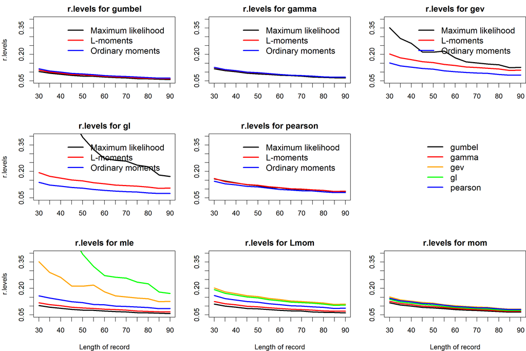

[1] “r.levels” [1] 200 [1] 22 31 32 41 60 61 62 63 66 67 68 74 75 78 80 81 82 [18] 83 84 85 88 91 92 93 94 96 102 109 110 127 128 136 138 140 [35] 147 163 165 204 283 291 [1] “done printint”

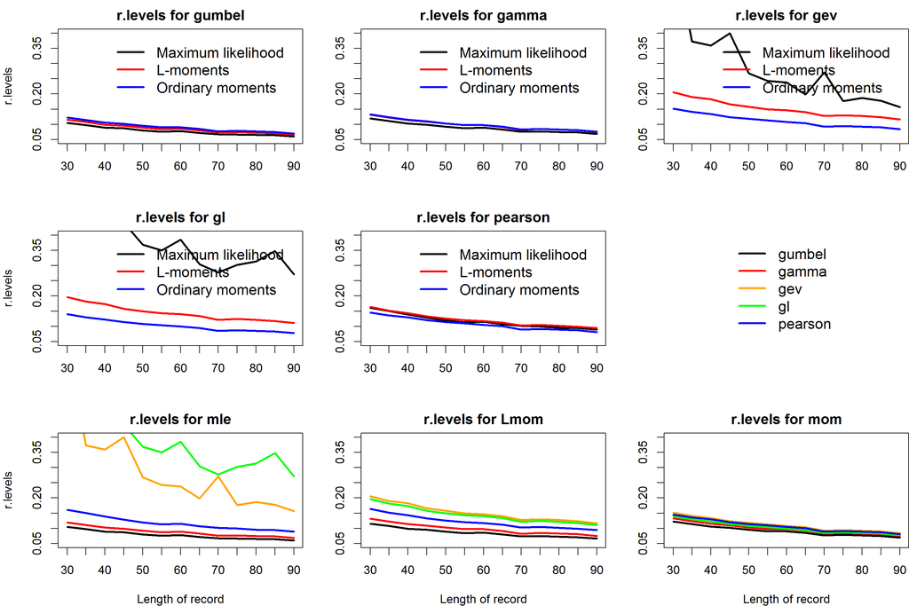

## KS

[1] 10 11 13 18 20 25 38 39 43 49 50 57 77 117 152 153 160 [18] 161 168 174 188 189 202 208 214 222 231 233 235 240 242 244 245 246 [35] 247 251 252 254 289 298 [1] “entered the plotting function” [1] 30 [1] 150

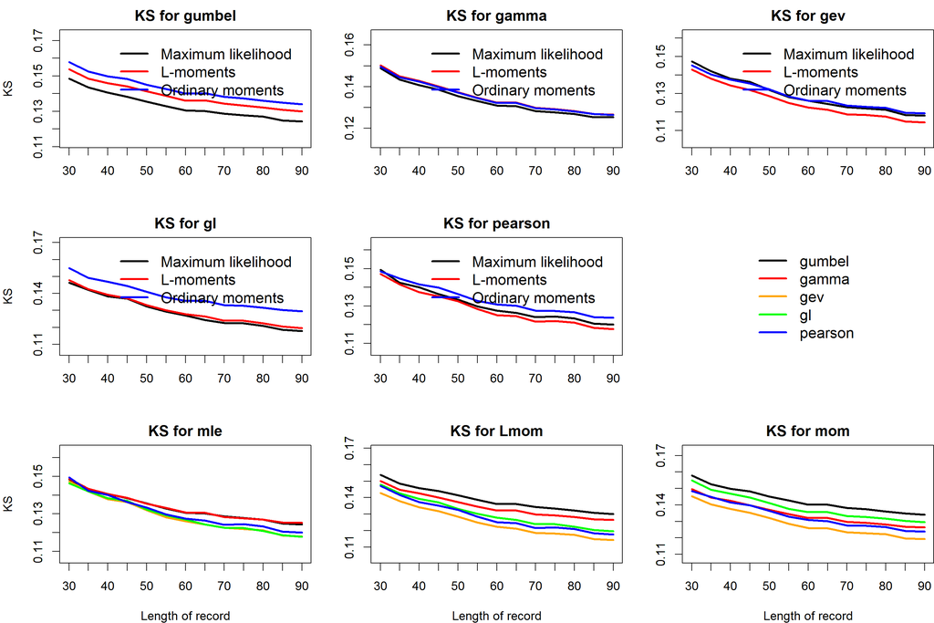

[1] 1 12 15 16 17 21 27 34 40 42 45 46 56 58 111 116 119 [18] 120 121 122 123 124 144 149 150 156 166 176 180 197 203 224 229 230 [35] 234 237 256 288 290 [1] “entered the plotting function” [1] 30 [1] 150

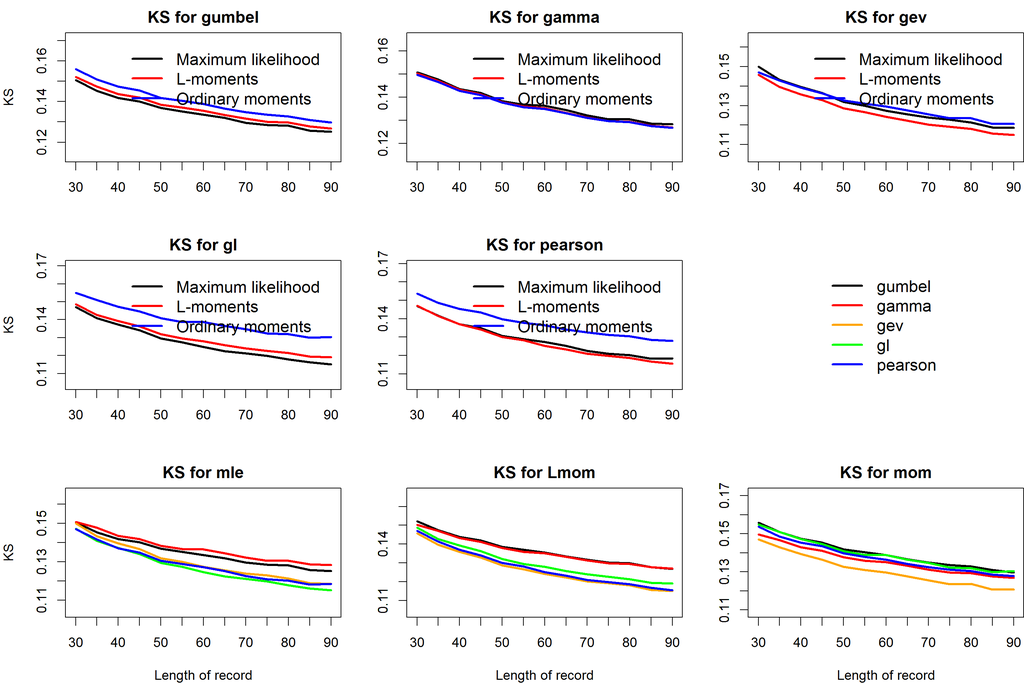

[1] 14 19 23 28 29 33 44 59 64 65 69 97 103 105 106 107 108 [18] 112 125 126 130 132 133 134 141 142 145 157 171 175 179 182 185 201 [35] 216 220 227 262 279 [1] “entered the plotting function” [1] 30 [1] 150

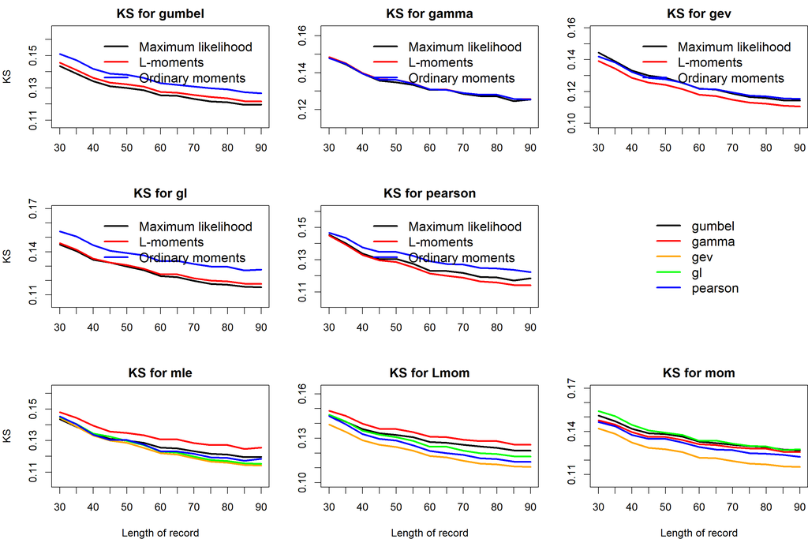

[1] 22 31 32 41 60 61 62 63 66 67 68 74 75 78 80 81 82 [18] 83 84 85 88 91 92 93 94 96 102 109 110 127 128 136 138 140 [35] 147 163 165 204 283 291 [1] “entered the plotting function” [1] 30 [1] 150

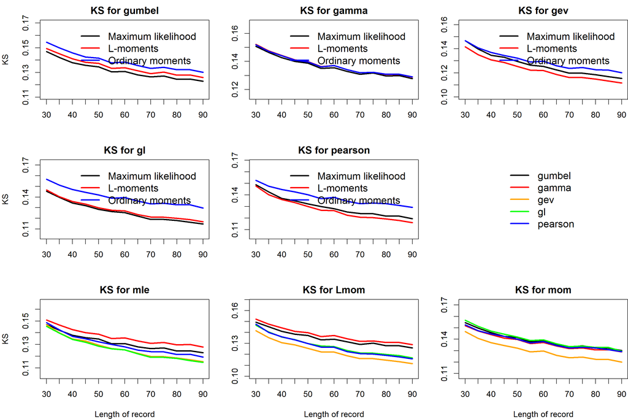

## AD

[1] 10 11 13 18 20 25 38 39 43 49 50 57 77 117 152 153 160 [18] 161 168 174 188 189 202 208 214 222 231 233 235 240 242 244 245 246 [35] 247 251 252 254 289 298 [1] “entered the plotting function” [1] 30 [1] 150

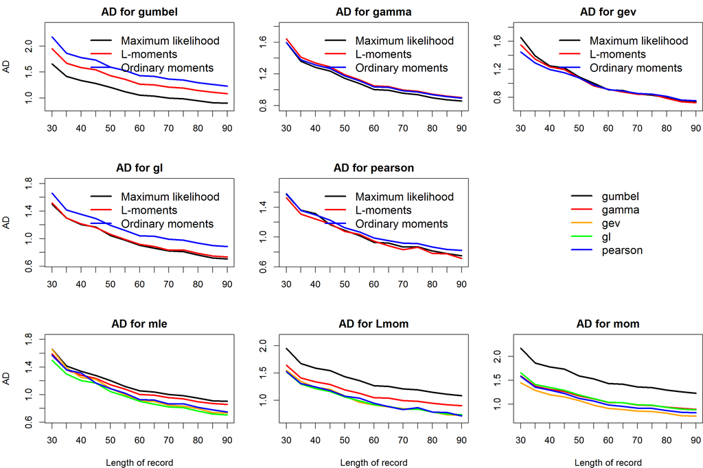

[1] 1 12 15 16 17 21 27 34 40 42 45 46 56 58 111 116 119 [18] 120 121 122 123 124 144 149 150 156 166 176 180 197 203 224 229 230 [35] 234 237 256 288 290 [1] “entered the plotting function” [1] 30 [1] 150

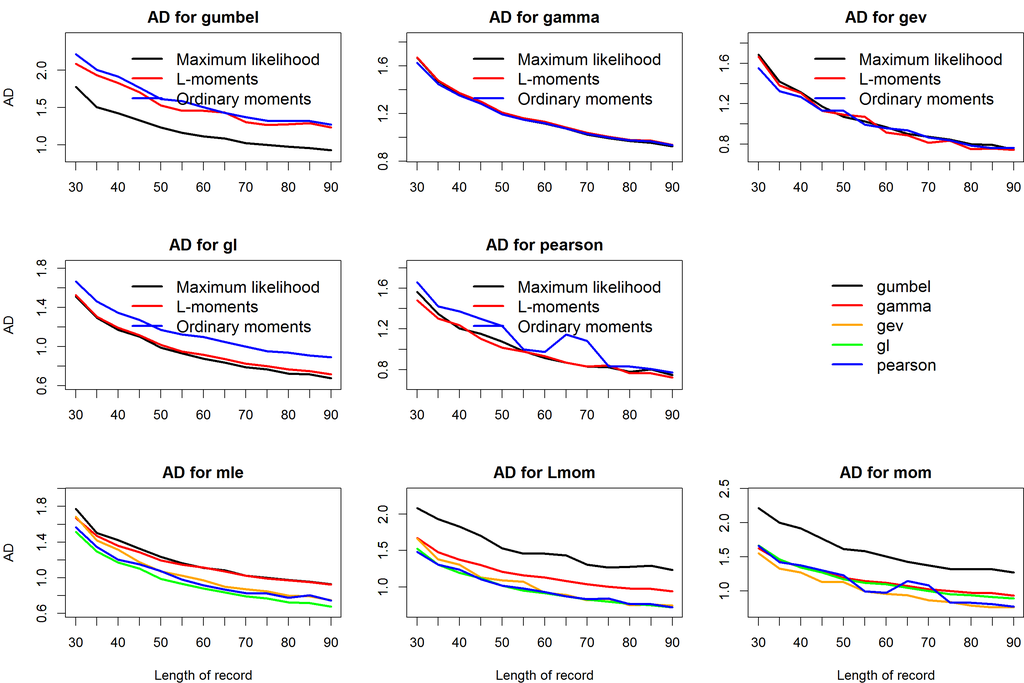

[1] 14 19 23 28 29 33 44 59 64 65 69 97 103 105 106 107 108 [18] 112 125 126 130 132 133 134 141 142 145 157 171 175 179 182 185 201 [35] 216 220 227 262 279 [1] “entered the plotting function” [1] 30 [1] 150

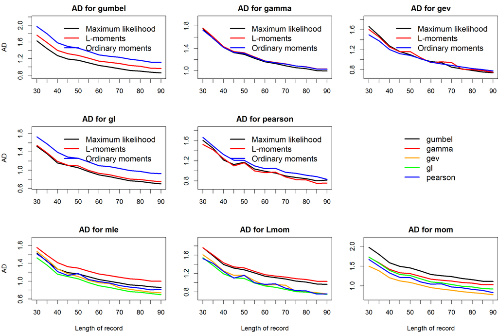

[1] 22 31 32 41 60 61 62 63 66 67 68 74 75 78 80 81 82 [18] 83 84 85 88 91 92 93 94 96 102 109 110 127 128 136 138 140 [35] 147 163 165 204 283 291 [1] “entered the plotting function” [1] 30 [1] 150

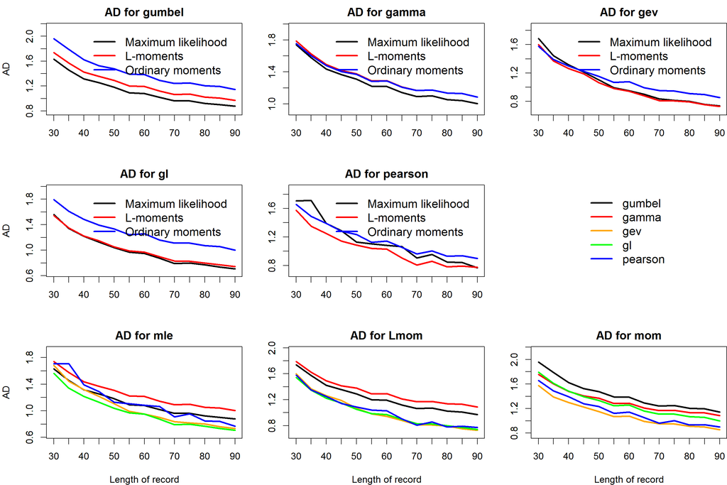